# Loan Status prediction

## by Esraa

## Investigation Overview

> In this presentation we will highlight some insights that help us to predict whether the user will be able to complete the loan or not and what are the features that we should take into consideration when taking a decision when some one ask for a loan.

## Dataset Overview

> We will wok on "Prosper Loan Data" data set which contains 113,937 loans with 81 variables on each loan, including loan amount, borrower rate (or interest rate), current loan status, borrower income, and many others.

## How the Employment status affect the loan status ?

> We found here that the most categeory that completed the loan are the full_time employed people followed by employed people , Which indicates that employemnt status may have impact on the loan status.

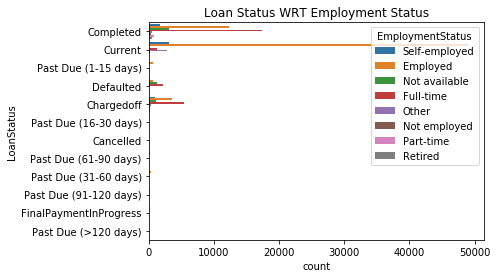

## What factors affect a loan’s outcome status?

> These are 10 feaures that affects the loan status and apparently the "LoanCurrentDaysDelinquent" feature is the strongest correlation co-efficient with loan status in the data frame

```
LoanStatus                         1.000000
InquiriesLast6Months               0.124671
TotalInquiries                     0.115713
CurrentDelinquencies               0.112822
LoanCurrentDaysDelinquent          0.677096
LoanFirstDefaultedCycleNumber      0.614666
LP_CustomerPrincipalPayments       0.401032
LP_CollectionFees                  0.264476
LP_GrossPrincipalLoss              0.616272
LP_NetPrincipalLoss                0.614375
LP_NonPrincipalRecoverypayments    0.234248
Name: LoanStatus, dtype: float64
```

As we can see, Here are the most correlated features with loan status

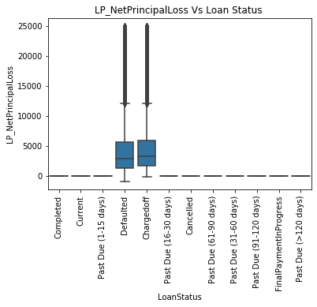

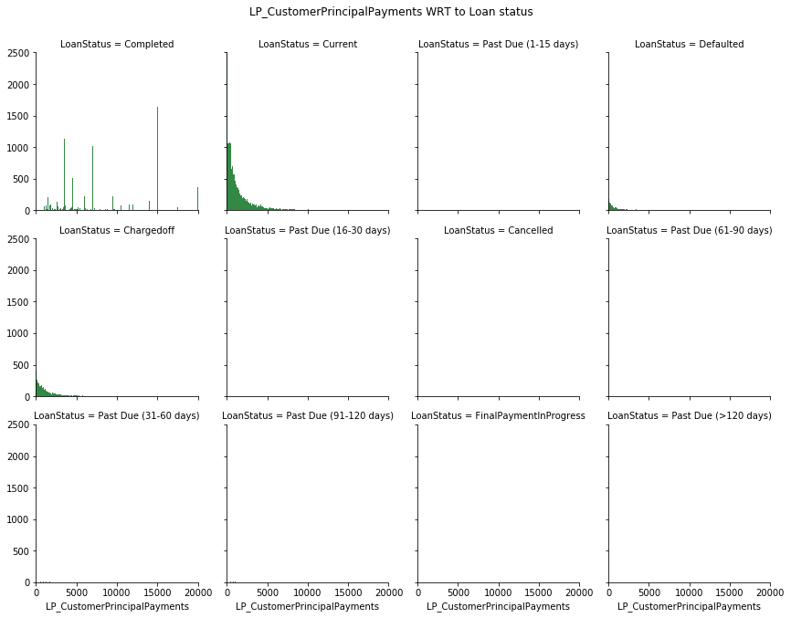

## What affects the borrower’s APR ?

```
EstimatedLoss                   -0.145701
ProsperRating (numeric)         -0.269389
ProsperRating (Alpha)           -0.269389
ProsperScore                    -0.274315
CurrentlyInGroup                -0.192651
PublicRecordsLast12Months       -0.110612
CreditGrade                      0.335248
ClosedDate                       0.288528
BorrowerAPR                      1.000000
BorrowerRate                     0.659202
LenderYield                      0.632452
EstimatedEffectiveYield          0.175127
EstimatedReturn                  0.144543
EmploymentStatus                 0.236216
GroupKey                         0.126615
CreditScoreRangeLower            0.103306
CreditScoreRangeUpper            0.103306
TotalInquiries                   0.106497
LoanCurrentDaysDelinquent        0.106230
LoanFirstDefaultedCycleNumber    0.106786
LoanMonthsSinceOrigination       0.243307
LoanOriginationDate              0.183008
LoanOriginationQuarter           0.242839
MonthlyLoanPayment               0.373667
LP_CustomerPayments              0.192216
LP_InterestandFees               0.126450
LP_GrossPrincipalLoss            0.134346
LP_NetPrincipalLoss              0.132243
Recommendations                  0.109949
Investors                        0.118336
Name: BorrowerAPR, dtype: float64
```

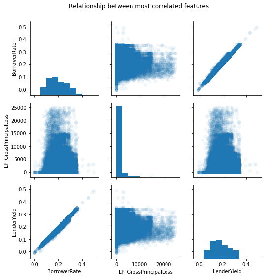

## Focusing on relation between the BorrowerRate and the LenderYield.

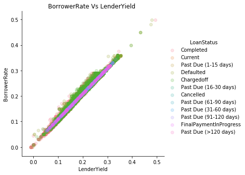

#### Are there differences between loans depending on how large the original loan amount was?

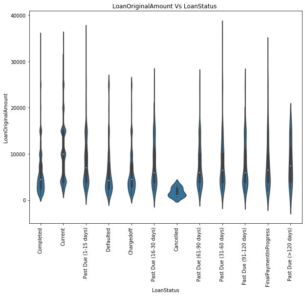

It is clear there are differences between loans according to thier original amount.